# Lab Four: Evaluation and Multi-Layer Perceptron

LJ Brown, Joe McGuire, Henry Warren, Mike Lefebvre, Xingming Qu

## 1. Business Understanding

Given the scale and popularity of social forums as platforms for communication, a machine learning based approach to auto-moderation may be necessary to help ensure that these platforms are moderated as prescribed by their builders. With the ability to automatically classify text bodies by topic, social forums could:

- Automatically tag content, and therefore allow users to filter it
- Automatically flag content with certain labels for human review
- Automatically require human approval before making content publicly visible if it is in a certain category
- Automatically block content from being posted if it is in a certain category

We believe that 90% general accuracy would be an acceptable rate of accuracy for this prediction task because it would be easy to augment the classifications with a combination of crowd sourced and in-house (human) moderation and because the consequences of false positives and negatives in this context are not overly severe. However, it is also necessary to note that accuracy may not necessary be the best method to evaluate models of this sort, as in cases where the data set is imbalanced, accuracy would likely give a poor reflection of the actual performance of our model.

## 2. Preparation(Dataset Selection)

In this lab, we use the dataset from our Lab1.

Dataset: BBCSport

All rights, including copyright, in the content of the original articles are owned by the BBC.

Reference: http://mlg.ucd.ie/datasets/bbc.html

### 2.1 Read document data

Read in document data as strings using Python. Read the data as raw text documents.

```python
# read txt file
def readtxt(filename):
    with open(filename, 'r',encoding='gb18030', errors='ignore') as file_to_read:
        content = file_to_read.read()
    return content
```

```python
#read all the documents
import numpy as np
import pandas as pd
import os,shutil
import matplotlib
import matplotlib.pyplot as plt
import warnings
import pickle
warnings.filterwarnings('ignore')

########################################Change your folder first#############################
folder='bbcsport'
folders=os.listdir(folder)
print('Document catagories are ',folders)

summary_text=[]
for item in folders:  # find each catagory's dir
    each_catagory=[]
    print('now reading',item,'docs...')
    path=os.path.join(folder,item)
    docs=os.listdir(path)
    for doc in docs:  #find each doc in a folder
        doc_dir= os.path.join(path, doc)
        each_catagory.append(readtxt(doc_dir))
    summary_text.append(each_catagory)
print('==============================')
it=0
for c in summary_text:
    print('There are',len(c),folders[it],'documents')
    it+=1

##summary_text contains the whole corpus, first index is catagories and second index is the number of document
```

```
Document catagories are  ['athletics', 'tennis', 'football', 'rugby', 'cricket']
now reading athletics docs...
now reading tennis docs...
now reading football docs...
now reading rugby docs...
now reading cricket docs...
==============================
There are 101 athletics documents
There are 100 tennis documents
There are 265 football documents
There are 147 rugby documents
There are 124 cricket documents
```

### 2.2 Pre-Processing

#### 2.2.1 Convert the corpus from raw text into a sparse encoded bag-of-words representation.

```python
## collect all the words from the dataset
corpus=[]
for each_catagory in summary_text:
    for each_doc in each_catagory:
        corpus.append(each_doc)

from sklearn.feature_extraction.text import CountVectorizer
# Encode bag-of-words and remove stop words
count_vect = CountVectorizer(max_df=0.8,min_df=0.0028,stop_words='english') #*** do we need to explain why min/max chosen?

corpus_bag_words = count_vect.fit_transform(corpus)
corpus_df = pd.DataFrame(data=corpus_bag_words.toarray(),columns=count_vect.get_feature_names()) #store as df

print('There are',len(corpus),'documents in the corpus, and each document has',\
      corpus_bag_words.shape[1],'features.') # this is a sparse matrix
print(corpus_df.shape)
```

```
There are 737 documents in the corpus, and each document has 5542 features.
(737, 5542)
```

```python
## make label list
label_length=[len(c) for c in summary_text]
label_list=[]
category=0
for i in label_length:
    for j in range(i):
        label_list.append(category)
    category+=1

y=np.array(label_list) # y contains each document's label
```

#### 2.3 Using PCA for dimensionality reduction

```python
from sklearn.decomposition import PCA

X = corpus_df
y=np.array(label_list)

def plot_explained_variance(pca):
    import plotly
    from plotly.graph_objs import Bar, Line
    from plotly.graph_objs import Scatter, Layout
    from plotly.graph_objs.scatter import Marker
    from plotly.graph_objs.layout import XAxis, YAxis
    plotly.offline.init_notebook_mode() # run at the start of every notebook

    explained_var = pca.explained_variance_ratio_
    cum_var_exp = np.cumsum(explained_var)

    plotly.offline.iplot({
        "data": [Bar(y=explained_var, name='individual explained variance'),
                 Scatter(y=cum_var_exp, name='cumulative explained variance')
            ],
        "layout": Layout(xaxis=XAxis(title='Principal components'), yaxis=YAxis(title='Explained variance ratio'))
    })

pca = PCA(n_components=500)
X_pca = pca.fit(X)
plot_explained_variance(pca)
```

[interactive chart not shown]

In general, we want PCA to retain 95% of the variance, as the remaining 5 percent of the variance is likely to be very spread out, and it could take exponentially more dimensions to capture the remaining 5% of our variance. We can see from the image above that when the principal components >= 475, the cumulative explained varience >= 95%. So 475 dimensions are required to adequately represent our text data.

```python
X = corpus_df
y = np.array(label_list)

pca = PCA(n_components=475)
X_pca = pca.fit(X).transform(X) # fit data and then transform it
```

```python
from sklearn.cross_validation import train_test_split
X_train,X_test,Y_train,Y_test = train_test_split(X_pca,y,test_size=0.2)
```

### 2.4 Describe the final dataset that is used for classification

The final dataset contains 737 documents. Each documents is a 475-d vector, which was generated by PCA.  
There are 5 classes:  
There are 101 athletics documents  
There are 124 cricket documents  
There are 265 football documents  
There are 147 rugby documents  
There are 100 tennis documents

```python
print(X_pca.shape)
```

```
(737, 475)
```

## 3. Evaluation

### 3.1 Choose and explain what metric(s) you will use to evaluate your algorithm’s generalization performance

In researching why accuracy is not a great evaluation metric, we discovered what's known as the "Accuracy Paradox," stating:

> Accuracy paradox for predictive analytics states that predictive models with a given level of accuracy may have greater predictive power than models with higher accuracy.  
> Source: https://en.wikipedia.org/wiki/Accuracy_paradox

The source is then perscriptive in its description, stating:

> It may be better to avoid the accuracy metric in favor of other metrics such as **precision** and **recall**.  
> Source: https://en.wikipedia.org/wiki/Accuracy_paradox

Given this paradox, accuracy may mistakenly perceived as a success metric, when a mix of precision and recall might be the better performance metric. Further research corroborated this hunch:

> Precision-Recall is a useful measure of success of prediction when the classes are very imbalanced. In information retrieval, precision is a measure of result relevancy, while recall is a measure of how many truly relevant results are returned.  
> Source: http://scikit-learn.org/stable/auto_examples/model_selection/plot_precision_recall.html

Therefore, we chose the f1_score method, with micro averaging, to evaluate our algorithm's generalization performance. The f1_score algorithm (with accuracy parameter set to "micro") operates as a weighted average of precision and recall that calculates metrics globally by counting the total true positives, false negatives, and false positives.  
Source: http://scikit-learn.org/stable/modules/generated/sklearn.metrics.f1_score.html

### 3.2 Choose the method you will use for dividing your data into training and testing

We used stratified K-fold cross validation because we have imbalanced classes in the test set and training set, as such, the proportion of classes should be consistent with the original data set. We decided on using 10 folds to get a large sampling of the performance of our algorithm on multiple subsamples, while still limiting the amount of computation time required for this project.

## 4. Modeling

### 4.1 Create a custom implementation of the multi-layer perceptron.

#### 4.1.1 When instantiated, use a selectable phi function for the initial layer: either sigmoid or linear

In this task, we include sigmoid and linear in a phi function. You can choose either of them by setting phi="sigmoid" or phi="linear". The implementation and detailed notes can be found below.

#### 4.1.2 Use a selectable cost function when instantiated: either quadratic or cross entropy

We use a similar idea from 4.1.1. You can choose either quadratic or cross entropy by setting objective_function="quadratic"/objective_function="cross_entropy". The implementation and detailed notes can be found below.

#### 4.1.3 Add support for any number of hidden layers (user customizable).

We rewrite the _initialize_weights as _initilize_layers. It uses a list(self.layers) to store W for each layer, and we use GaussianInitial to get better performance. The implementation and detailed notes can be found below.

```python
from sklearn.metrics import accuracy_score
from sklearn.preprocessing import StandardScaler
from sklearn.metrics import accuracy_score
from sklearn.metrics import precision_score, recall_score, f1_score
```

```python
# Example adapted from https://github.com/rasbt/python-machine-learning-book/blob/master/code/ch12/ch12.ipynb
# Original Author: Sebastian Raschka

# This is the optional book we use in the course, excellent intuitions and straightforward programming examples
# please note, however, that this code has been manipulated to reflect our assumptions and notation.
import numpy as np
from scipy.special import expit
import sys
import pandas as pd

# start with a simple base classifier, which can't be fit or predicted
# it only has internal classes to be used by classes that will subclass it
class MultiLayerPerceptronBase(object):

    def __init__(self, n_layers=2, n_hidden=30, C=0.0, epochs=500, eta=0.001, random_state=None, \
                phi="sigmoid", objective_function="quadratic"):
        np.random.seed(random_state)
        self.n_layers = n_layers
        self.n_hidden = n_hidden
        self.l2_C = C
        self.epochs = epochs
        self.eta = eta
        self.phi = phi
        self.objective_function = objective_function

    ## These two function is used to Grid search
    def get_params(self, deep=True):
        return {'n_layers':self.n_layers, 'C':self.l2_C, 'epochs':self.epochs, 'eta':self.eta,
                'n_hidden':self.n_hidden, 'objective_function':self.objective_function, 'phi':self.phi}

    def set_params(self, **parameters):
        for parameter, value in parameters.items():
            self.__setattr__(parameter, value)
        return self

    @staticmethod
    def _encode_labels(y):
        """Encode labels into one-hot representation"""
        onehot = pd.get_dummies(y).values.T
        return onehot

    ############################ 4.1.3 begins here #########################
    # we rewrite the _initialize_weights as _initilize_layers
    def _initilize_layers(self):

        # [W1, W2, ..., Wn]
        self.layers = []

        # single layer
        if self.n_layers == 1:

            # create first layer
            self.layers += [ self._create_layer( size_in=self.n_features_, size_out=self.n_output_  ) ]

        # multi layer
        if self.n_layers > 1:

            # create first layer
            self.layers += [ self._create_layer( size_in=self.n_features_, size_out=self.n_hidden ) ]

            if self.n_layers > 2:

                # create middle/hidden layers
                self.layers += [ self._create_layer( size_in=self.n_hidden, size_out=self.n_hidden ) for i in range(self.n_layers -2) ]

            # creat last/output layer
            self.layers += [ self._create_layer( size_in=self.n_hidden, size_out=self.n_output_ )]

        assert len(self.layers) >= 1

    @staticmethod
    # this function is used for _initilize_layers
    def _create_layer(size_in, size_out):
        # using GaussianInitial to get better performance
        W1 = np.random.randn(size_out, size_in + 1)
        W1[:,1:] = W1[:,1:]/np.sqrt(size_in + 1) # don't saturate the neuron
        W1[:,:1] = 0 # common practice to start with zero bias
        return W1
    ############################ 4.1.3 ends here #########################

    @staticmethod
    ############################ 4.1.1 begins here #########################
    # here we add two activation functions ---sigmoid and linear
    def _sigmoid(z):
        """Use scipy.special.expit to avoid overflow"""
        # 1.0 / (1.0 + np.exp(-z))
        return expit(z)

    @staticmethod
    def _linear(z):
        return z

    # we seal activation functions to phi
    def _phi(self, z):
        if self.phi == "sigmoid":
            return self._sigmoid(z)
        if self.phi == "linear":
            return self._linear(z)

    # define each function's derivative
    def _phi_grad(self, a):
        if self.phi == "sigmoid":
            return a*(1-a)
        if self.phi == "linear":
            return 1
     ############################ 4.1.1 ends here #########################

    ############################ 4.1.2 begins here #########################
    # Here we add two cost function -- MSE and Cross Entropy
    @staticmethod
    def _MSE(Y_enc, Y_hat):
        cost = np.mean((Y_enc-Y_hat)**2)
        return cost

    @staticmethod
    def _cross_entropy(Y_enc, Y_hat):
        cost = -np.mean(np.nan_to_num((Y_enc*np.log(Y_hat)+(1-Y_enc)*np.log(1-Y_hat))))
        return cost

    # we seal these two function into _cost
    def _cost(self,Y_hat,Y_enc):
        '''Get the objective function value'''
        if self.objective_function == "quadratic":
            cost = self._MSE(Y_enc, Y_hat)
        if self.objective_function == "cross_entropy":
            cost = self._cross_entropy(Y_enc, Y_hat)
        L2_term = self._L2_reg(self.l2_C)
        return cost + L2_term

    # modify L2_reg
    def _L2_reg(self,lambda_):
        """Compute L2-regularization cost"""
        # only compute for non-bias terms
        L=0
        for w in self.layers:
            L+=np.mean(w[:, 1:] ** 2)
        return (lambda_/2.0) * np.sqrt(L)

    ############################ 4.1.2 ends here #########################

    @staticmethod
    def _add_bias_unit(X, how='column'):
        """Add bias unit (column or row of 1s) to array at index 0"""
        if how == 'column':
            ones = np.ones((X.shape[0], 1))
            X_new = np.hstack((ones, X))
        elif how == 'row':
            ones = np.ones((1, X.shape[1]))
            X_new = np.vstack((ones, X))
        return X_new

    def _feedforward(self, X):

        # Create first A from X.T with an extra row for the biases
        A1 = self._add_bias_unit(X.T, how='row')

        # initilize list of As and Zs
        As = [A1]
        Zs = []

        # compute intermediate As and Zs
        for i, W in enumerate(self.layers[:-1]):
            Zs += [ W @ As[-1] ]
            A_next = self._phi(Zs[-1])
            A_next = self._add_bias_unit(A_next, how='row')
            As += [ A_next ]

        # do not add a bias row to final A
        Z_final = self.layers[-1] @ As[-1]
        A_final = self._sigmoid(Z_final)
        Zs += [ Z_final ]
        As += [ A_final ]

        return As, Zs

    def predict(self, X):
        """Predict class labels"""
        As, Zs = self._feedforward(X)
        y_pred = np.argmax(As[-1], axis=0)

        return y_pred
```

```python
class MultiLayerPerceptron( MultiLayerPerceptronBase ):
    def fit(self, X, y):
        """ Learn weights from training data.
            Input X should be a matrix with separate instances
            in each row, and separate features in each column.
            The target variable, y, should be integer values
            starting from zero, that represent the unique classes.
        """

        # copy over the data and one-hot-encode Y
        X_data, y_data = X.copy(), y.copy()
        Y_enc = self._encode_labels(y)

        # init weights and setup matrices
        self.n_features_ = X_data.shape[1]
        self.n_output_ = Y_enc.shape[0]
        self._initilize_layers()
        ############################ 4.1.5 begins here #########################
        self.grad_w=[]
        for x in range(len(self.layers)):
            self.grad_w.append(np.empty(self.epochs))
        ############################ 4.1.5 ends here #########################

        # run training for specified number of iterations
        self.cost_ = []
        self.score_ = []
        self.score_.append(f1_score(y_data,self.predict(X_data),average='micro'))
        for i in range(self.epochs):

            # feedforward all instances
            As, Zs = self._feedforward(X_data)
            cost = self._cost(As[-1],Y_enc)
            self.cost_.append(cost)

            # compute gradient via backpropagation
            gradients = self._get_gradient(As, Y=Y_enc)

            ############################ 4.1.5 begins here #########################
            for j in range(len(gradients)):
                self.grad_w[j][i]=np.mean(abs(gradients[j]))
            ############################ 4.1.5 ends here #########################

            # update each matrix to minimize objective function
            for Wi, gradi in zip(self.layers, gradients):
                Wi -= self.eta * gradi
            self.score_.append(f1_score(y_data,self.predict(X_data),average='micro'))

        return self

    # just need a different gradient calculation
    def _get_gradient(self, As, Y):

        # Compute gradient step using backpropagation.

        # calculate sensitivities for V_last -> V_1
        Ws_reversed = list(reversed(self.layers))
        As_reversed = list(reversed(As))
        Vs_reversed = []

        # calculate last layer sensistivity first
        ################ Vn is decided by cost function #########

        if self.objective_function == "quadratic":
            V_n = -2 * (Y - As_reversed[0]) * self._phi_grad(As_reversed[0])

        if self.objective_function == "cross_entropy":
            V_n = (As_reversed[0]-Y)

        Vs_reversed += [ V_n ]

        # calculate second to last layer sensistivity
        V_nm1 = Ws_reversed[0].T @ Vs_reversed[-1] * self._phi_grad(As_reversed[1])
        Vs_reversed += [ V_nm1 ]

        # calculate remaining sensitivities
        for Ai, Wi in zip(As_reversed[2:-1], Ws_reversed[1:-1]):
            V_i = Wi.T @ Vs_reversed[-1][1:,:] * self._phi_grad(Ai)
            Vs_reversed += [ V_i ]

        # calculate the gradient
        # initilize gradients list
        gradients_reversed = []

        # calculate final W gradient
        grad_n = Vs_reversed[0] @ As_reversed[1].T
        gradients_reversed += [ grad_n ]

        # calculate remaning gradients
        for V,A in zip(Vs_reversed[1:], As_reversed[2:]):
            grad_i = V[1:,:] @ A.T
            gradients_reversed += [ grad_i ]

        # regularize weights that are not bias terms
        l2_gradients_reversed=[]
        for Wi, gradi in zip(Ws_reversed, gradients_reversed):
            gradi[:, 1:] += Wi[:, 1:] * self.l2_C
            l2_gradients_reversed.append(gradi)

        # return gradients [grad1, ..., gradn]
        return list(reversed(l2_gradients_reversed))
```

```python
import matplotlib.pyplot as plt
%matplotlib inline
plt.style.use('ggplot')

def print_result(nn,X_train,y_train,X_test,y_test,title="",color="red"):

    print("=================")
    print(title,":")
    yhat = nn.predict(X_train)

    ################ We are using micro f1_score in this lab #########################
    print('Resubstitution f1:',f1_score(y_train,yhat,average='micro'))

    yhat = nn.predict(X_test)
    print('Validation f1:',f1_score(y_test,yhat,average='micro'))

    if hasattr(nn,'val_score_'):
        plt.plot(range(len(nn.val_score_)), nn.val_score_, color=color,label=title)
        plt.ylabel('Validation f1_score')
    else:
        plt.plot(range(len(nn.score_)), nn.score_, color=color,label=title)
        plt.ylabel('Resub f1_score')

    plt.xlabel('Epochs')
    plt.tight_layout()
    plt.legend(loc='best')
    plt.grid(True)
```

```
=================
Cross Entropy Loss :
Resubstitution f1: 1.0
Validation f1: 1.0
=================
Quadratic Loss :
Resubstitution f1: 0.6502546689303905
Validation f1: 0.6013513513513513
```

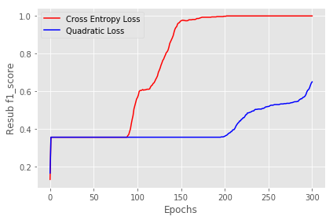

```python
from sklearn.metrics import accuracy_score

# train neural net
sigmoid_quadratic = MultiLayerPerceptron(n_layers=4, n_hidden=40, epochs=300,C=0.01 , \
                           eta=0.001,phi="sigmoid",objective_function="quadratic")

sigmoid_cross_entropy = MultiLayerPerceptron(n_layers=4, n_hidden=40, epochs=300,C=0.01 , \
                           eta=0.001,phi="sigmoid",objective_function="cross_entropy")
sigmoid_quadratic.fit( X_train, Y_train )
sigmoid_cross_entropy.fit( X_train, Y_train )
print_result(sigmoid_cross_entropy,X_train,Y_train,X_test,Y_test,title="Cross Entropy Loss",color="red")
print_result(sigmoid_quadratic,X_train,Y_train,X_test,Y_test,title="Quadratic Loss",color="blue")

plt.show()
```

```
=================
Cross Entropy Loss :
Resubstitution f1: 1.0
Validation f1: 0.9932432432432432
=================
Quadratic Loss :
Resubstitution f1: 1.0
Validation f1: 0.9797297297297298
```

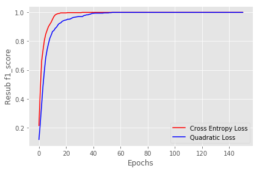

```python
# train neural net
linear_quadratic = MultiLayerPerceptron(n_layers=4, n_hidden=40, epochs=150, C=0.01 ,\
                           eta=0.0001,phi="linear",objective_function="quadratic")

linear_cross_entropy = MultiLayerPerceptron(n_layers=4, n_hidden=40, epochs=150, C=0.01 ,\
                           eta=0.0001,phi="linear",objective_function="cross_entropy")

linear_quadratic.fit( X_train, Y_train )
linear_cross_entropy.fit( X_train, Y_train )
print_result(linear_quadratic,X_train,Y_train,X_test,Y_test,title="Cross Entropy Loss",color="red")
print_result(linear_cross_entropy,X_train,Y_train,X_test,Y_test,title="Quadratic Loss",color="blue")

plt.show()
```

#### 4.1.4 Tune the hyper-parameters of your MLP model (phi function, objective function, and number of layers)

We use StratifiedKFold and GridSearchCV to select the best hyper-parameters.

```python
from sklearn.model_selection import GridSearchCV
from sklearn.model_selection import cross_val_score
from sklearn.model_selection import KFold, ShuffleSplit
from sklearn.model_selection import StratifiedKFold, StratifiedShuffleSplit

from sklearn.metrics import make_scorer, accuracy_score
from sklearn.metrics import precision_score, recall_score, f1_score
my_scorer = make_scorer(f1_score,average='micro')
# # Set GridSearchCV parameters
parameters = [{'n_layers':[3,5,7],'eta':[0.001,0.0001],'phi':['sigmoid','linear'],'objective_function':['quadratic','cross_entropy']}]
gs = GridSearchCV(estimator=MultiLayerPerceptron(n_hidden=40,epochs=100),param_grid=parameters,cv=StratifiedKFold(n_splits=3),scoring=my_scorer);
gs.fit(X_pca,y);
```

```python
gs_results = pd.DataFrame(gs.cv_results_)
gs_results = gs_results[['rank_test_score','mean_test_score','std_test_score','param_n_layers',
                         'param_eta','param_phi']]
gs_results.sort_values('rank_test_score')
```

|  | rank_test_score | mean_test_score | std_test_score | param_n_layers | param_eta | param_phi |
| --- | --- | --- | --- | --- | --- | --- |
| 13 | 1 | 0.986431 | 0.010180 | 3 | 0.0001 | linear |
| 17 | 2 | 0.979647 | 0.008645 | 5 | 0.0001 | linear |
| 3 | 3 | 0.978290 | 0.013672 | 3 | 0.001 | linear |
| 15 | 4 | 0.976934 | 0.013399 | 3 | 0.0001 | linear |
| 2 | 5 | 0.975577 | 0.014426 | 3 | 0.001 | sigmoid |
| 19 | 6 | 0.964722 | 0.016373 | 5 | 0.0001 | linear |
| 23 | 7 | 0.963365 | 0.018335 | 7 | 0.0001 | linear |
| 21 | 7 | 0.963365 | 0.011843 | 7 | 0.0001 | linear |
| 0 | 9 | 0.569878 | 0.062460 | 3 | 0.001 | sigmoid |
| 10 | 10 | 0.359566 | 0.000777 | 7 | 0.001 | sigmoid |
| 22 | 10 | 0.359566 | 0.000777 | 7 | 0.0001 | sigmoid |
| 12 | 10 | 0.359566 | 0.000777 | 3 | 0.0001 | sigmoid |
| 14 | 10 | 0.359566 | 0.000777 | 3 | 0.0001 | sigmoid |
| 6 | 10 | 0.359566 | 0.000777 | 5 | 0.001 | sigmoid |
| 16 | 10 | 0.359566 | 0.000777 | 5 | 0.0001 | sigmoid |
| 18 | 10 | 0.359566 | 0.000777 | 5 | 0.0001 | sigmoid |
| 4 | 10 | 0.359566 | 0.000777 | 5 | 0.001 | sigmoid |
| 20 | 10 | 0.359566 | 0.000777 | 7 | 0.0001 | sigmoid |
| 8 | 10 | 0.359566 | 0.000777 | 7 | 0.001 | sigmoid |
| 9 | 20 | 0.137042 | 0.001438 | 7 | 0.001 | linear |
| 7 | 20 | 0.137042 | 0.001438 | 5 | 0.001 | linear |
| 5 | 20 | 0.137042 | 0.001438 | 5 | 0.001 | linear |
| 1 | 20 | 0.137042 | 0.001438 | 3 | 0.001 | linear |
| 11 | 20 | 0.137042 | 0.001438 | 7 | 0.001 | linear |

#### 4.1.5 Visualize the magnitude of the gradients in each layer of the neural network versus the training iteration. Do the gradients stay consistent in each layer?

```python
def draw(clf):
    plt.plot(abs(clf.grad_w[0][10:]), label='w1')
    plt.plot(abs(clf.grad_w[1][10:]), label='w2')
    plt.plot(abs(clf.grad_w[2][10:]), label='w3')
    plt.plot(abs(clf.grad_w[3][10:]), label='w4')
    plt.plot(abs(clf.grad_w[4][10:]), label='w5')
    plt.legend()
    plt.ylabel('Average gradient magnitude')
    plt.xlabel('Iteration')
    plt.show()

sigmoid_cross_entropy = MultiLayerPerceptron(n_layers=5, n_hidden=40, epochs=1000,C=0.01 , \
                           eta=0.001,phi="sigmoid",objective_function="cross_entropy")

sigmoid_cross_entropy.fit( X_train, Y_train )
```

```
<__main__.MultiLayerPerceptron at 0x7fd709880c50>
```

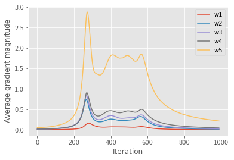

```python
ax = plt.subplot(1,1,1)
draw(sigmoid_cross_entropy)
```

From the above picture we can see the last layer has the largest magnitude. The front layers have smaller magnitude. After 1000 epochs the gradients converge. The picture shows the gradient vanishing problem. The first layer (closer to the input) of the neural network has the smallest gradient magnitude.

Note: Relu is not implemented now, you will find the gradients of Relu at the end of this notebook.

## 5. Exceptional Work

### 5.1 Implement two more phi functions: ReLU and SiLU

```python
class FinalMultiLayerPerceptron( MultiLayerPerceptron ):

    ########### add two activation functions ################
    @staticmethod
    def _relu(z):
        return np.maximum(0,z.copy())

    @staticmethod
    def _Silu(z):
        return z*expit(z)

    def _phi(self, z):
        if self.phi == "sigmoid":
            return self._sigmoid(z)
        if self.phi == "linear":
            return self._linear(z)
        if self.phi == "relu":
            return self._relu(z)
        if self.phi == "silu":
            return self._Silu(z)

    # define each function's derivative
    def _phi_grad(self, a,z):
        if self.phi == "sigmoid":
            return a*(1-a)
        if self.phi == "linear":
            return 1
        if self.phi == "relu":
            a[a<=0]=0
            a[a>0]=1
            return a
        if self.phi == "silu":
            return a+ z*(1-a)

    def _feedforward(self, X):
        # Create first A from X.T with an extra row for the biases
        A1 = self._add_bias_unit(X.T, how='row')

        # initilize list of As and Zs
        As = [A1]
        Zs = []
        Asigmoid=[A1]

        # compute intermediate As and Zs
        #### We add a new term Asigmoid_next to store Z's sigmoid value, which is uesd to compute silu's derivative
        for i, W in enumerate(self.layers[:-1]):
            Zs += [ W @ As[-1] ]

            Asigmoid_next = self._sigmoid(Zs[-1])
            Asigmoid_next = self._add_bias_unit(Asigmoid_next, how='row')

            A_next = self._phi(Zs[-1])
            A_next = self._add_bias_unit(A_next, how='row')

            As += [ A_next ]
            Asigmoid += [ Asigmoid_next ]

        # do not add a bias row to final A
        Z_final = self.layers[-1] @ As[-1]
        A_final = self._sigmoid(Z_final)
        Zs += [ Z_final ]
        As += [ A_final ]
        Asigmoid += [ A_final ]

        return As, Zs,Asigmoid

    def fit(self, X, y):
        """ Learn weights from training data.
            Input X should be a matrix with separate instances
            in each row, and separate features in each column.
            The target variable, y, should be integer values
            starting from zero, that represent the unique classes.
        """

        # copy over the data and one-hot-encode Y
        X_data, y_data = X.copy(), y.copy()
        Y_enc = self._encode_labels(y)

        # init weights and setup matrices
        self.n_features_ = X_data.shape[1]
        self.n_output_ = Y_enc.shape[0]
        self._initilize_layers()
        ############################ 4.1.5 begins here #########################
        self.grad_w=[]
        for x in range(len(self.layers)):
            self.grad_w.append(np.empty(self.epochs))
        ############################ 4.1.5 ends here #########################

        # run training for specified number of iterations
        self.cost_ = []
        self.score_ = []
        self.score_.append(f1_score(y_data,self.predict(X_data),average='micro'))
        for i in range(self.epochs):

            # feedforward all instances
            As, Zs,Asigmoid = self._feedforward(X_data)
            cost = self._cost(As[-1],Y_enc)
            self.cost_.append(cost)

            # compute gradient via backpropagation
            gradients = self._get_gradient(As,Y_enc,Asigmoid)

            ############################ 4.1.5 begins here #########################
            for j in range(len(gradients)):
                self.grad_w[j][i]=np.mean(abs(gradients[j]))
            ############################ 4.1.5 ends here #########################

            # update each matrix to minimize objective function
            for Wi, gradi in zip(self.layers, gradients):
                Wi -= self.eta * gradi
            self.score_.append(f1_score(y_data,self.predict(X_data),average='micro'))

        return self

    def predict(self, X):
        """Predict class labels"""

        As, Zs,_ = self._feedforward(X)
        y_pred = np.argmax(As[-1], axis=0)

        return y_pred

    # just need a different gradient calculation
    def _get_gradient(self, As, Y, Asigmoid):

        # Compute gradient step using backpropagation.

        # calculate sensitivities for V_last -> V_1
        Ws_reversed = list(reversed(self.layers))
        As_reversed = list(reversed(As))
        Asigmoid_reversed = list(reversed(Asigmoid))

        Vs_reversed = []

        # calculate last layer sensistivity first
        ################ Vn is decided by cost function #########

        if self.objective_function == "quadratic":
            V_n = -2 * (Y - As_reversed[0]) * self._phi_grad(As_reversed[0],Asigmoid_reversed[0])

        if self.objective_function == "cross_entropy":
            V_n = (As_reversed[0]-Y)

        Vs_reversed += [ V_n ]

        # calculate second to last layer sensistivity
        V_nm1 = Ws_reversed[0].T @ Vs_reversed[-1] * self._phi_grad(As_reversed[1],Asigmoid_reversed[1])
        Vs_reversed += [ V_nm1 ]

        # calculate remaining sensitivities
        for Ai, Wi, Zi in zip(As_reversed[2:-1], Ws_reversed[1:-1], Asigmoid_reversed[2:-1]):
            V_i = Wi.T @ Vs_reversed[-1][1:,:] * self._phi_grad(Ai,Zi)
            Vs_reversed += [ V_i ]

        # calculate the gradient
        # initilize gradients list
        gradients_reversed = []

        # calculate final W gradient
        grad_n = Vs_reversed[0] @ As_reversed[1].T
        gradients_reversed += [ grad_n ]

        # calculate remaning gradients
        for V,A in zip(Vs_reversed[1:], As_reversed[2:]):
            grad_i = V[1:,:] @ A.T
            gradients_reversed += [ grad_i ]

        # regularize weights that are not bias terms
        l2_gradients_reversed=[]
        for Wi, gradi in zip(Ws_reversed, gradients_reversed):
            gradi[:, 1:] += Wi[:, 1:] * self.l2_C
            l2_gradients_reversed.append(gradi)

        # return gradients [grad1, ..., gradn]
        return list(reversed(l2_gradients_reversed))
```

```
=================
Cross Entropy Loss :
Resubstitution f1: 1.0
Validation f1: 0.9797297297297298
=================
Quadratic Loss :
Resubstitution f1: 1.0
Validation f1: 0.9864864864864865
```

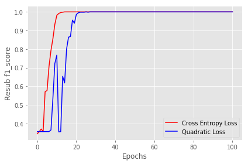

```python
# train neural net
relu_quadratic = FinalMultiLayerPerceptron(n_layers=4, n_hidden=40, epochs=100, C=0.01 ,\
                           eta=0.001,phi="relu",objective_function="quadratic")

relu_cross_entropy = FinalMultiLayerPerceptron(n_layers=4, n_hidden=40, epochs=100,C=0.01 , \
                           eta=0.001,phi="relu",objective_function="cross_entropy")

relu_quadratic.fit( X_train, Y_train )
relu_cross_entropy.fit( X_train, Y_train )

print_result(relu_cross_entropy,X_train,Y_train,X_test,Y_test,title="Cross Entropy Loss",color="red")
print_result(relu_quadratic,X_train,Y_train,X_test,Y_test,title="Quadratic Loss",color="blue")

plt.show()
```

```
=================
Cross Entropy Loss :
Resubstitution f1: 1.0
Validation f1: 0.9864864864864865
=================
Quadratic Loss :
Resubstitution f1: 1.0
Validation f1: 0.9797297297297298
```

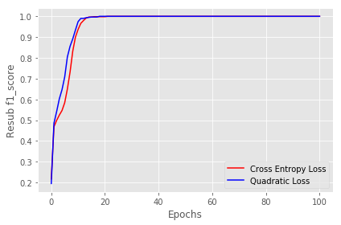

```python
# train neural net
silu_quadratic = FinalMultiLayerPerceptron(n_layers=4, n_hidden=40, epochs=100, C=0.01 ,\
                           eta=0.001,phi="silu",objective_function="quadratic")

silu_cross_entropy = FinalMultiLayerPerceptron(n_layers=4, n_hidden=40, epochs=100, C=0.01 ,\
                           eta=0.001,phi="silu",objective_function="cross_entropy")

silu_quadratic.fit( X_train, Y_train )
silu_cross_entropy.fit( X_train, Y_train )

print_result(silu_cross_entropy,X_train,Y_train,X_test,Y_test,title="Cross Entropy Loss",color="red")
print_result(silu_quadratic,X_train,Y_train,X_test,Y_test,title="Quadratic Loss",color="blue")

plt.show()
```

### 5.2 Compare their performance to the linear and sigmoid phi functions.

```
=================
Sigmoid Loss :
Resubstitution f1: 0.9966044142614601
Validation f1: 0.9864864864864865
=================
Linear Loss :
Resubstitution f1: 1.0
Validation f1: 0.9864864864864865
=================
Relu Loss :
Resubstitution f1: 1.0
Validation f1: 0.9797297297297298
=================
Silu Loss :
Resubstitution f1: 1.0
Validation f1: 0.9797297297297298
```

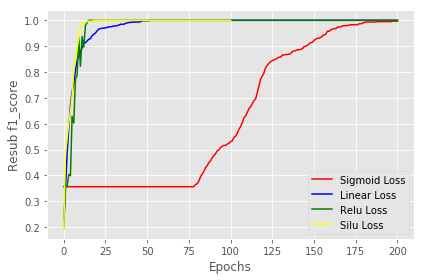

```python
sigmoid_cross_entropy = FinalMultiLayerPerceptron(n_layers=4, n_hidden=40, epochs=200,C=0.1 ,\
                           eta=0.001,phi="sigmoid",objective_function="cross_entropy")

linear_cross_entropy = FinalMultiLayerPerceptron(n_layers=4, n_hidden=40, epochs=200,C=0.1 ,\
                           eta=0.0001,phi="linear",objective_function="cross_entropy")

relu_cross_entropy = FinalMultiLayerPerceptron(n_layers=4, n_hidden=40, epochs=200,C=0.1 ,\
                           eta=0.001,phi="relu",objective_function="cross_entropy")

silu_cross_entropy = FinalMultiLayerPerceptron(n_layers=4, n_hidden=40, epochs=200,C=0.1 , \
                           eta=0.001,phi="silu",objective_function="cross_entropy")

sigmoid_cross_entropy.fit( X_train, Y_train )
linear_cross_entropy.fit( X_train, Y_train )
relu_cross_entropy.fit( X_train, Y_train )
silu_cross_entropy.fit( X_train, Y_train )

print_result(sigmoid_cross_entropy,X_train,Y_train,X_test,Y_test,title="Sigmoid Loss",color="red")
print_result(linear_cross_entropy,X_train,Y_train,X_test,Y_test,title="Linear Loss",color="blue")
print_result(relu_cross_entropy,X_train,Y_train,X_test,Y_test,title="Relu Loss",color="green")
print_result(silu_quadratic,X_train,Y_train,X_test,Y_test,title="Silu Loss",color="yellow")

plt.show()
```

```python
######## using epochs=60 to reduce time ##########
sigmoid_cross_entropy = FinalMultiLayerPerceptron(n_layers=4, n_hidden=40, epochs=60,C=0.1 ,\
                           eta=0.001,phi="sigmoid",objective_function="cross_entropy")

linear_cross_entropy = FinalMultiLayerPerceptron(n_layers=4, n_hidden=40, epochs=60,C=0.1 ,\
                           eta=0.0001,phi="linear",objective_function="cross_entropy")

relu_cross_entropy = FinalMultiLayerPerceptron(n_layers=4, n_hidden=40, epochs=60,C=0.1 ,\
                           eta=0.001,phi="relu",objective_function="cross_entropy")

silu_cross_entropy = FinalMultiLayerPerceptron(n_layers=4, n_hidden=40, epochs=60,C=0.1 , \
                           eta=0.001,phi="silu",objective_function="cross_entropy")
```

```python
def ourStratifiedKFold(clf,splitN,testsize,X,Y):
    # select cross validation
    cv = StratifiedShuffleSplit(n_splits=splitN,test_size=testsize)
    fold=cv.split(X,Y)
    X_train_Stratified = []
    X_test_Stratified = []
    y_train_Stratified = []
    y_test_Stratified = []
    for train_index, test_index in fold:
        X_train_Stratified.append(X_pca[train_index])
        X_test_Stratified.append(X_pca[test_index])
        y_train_Stratified.append(y[train_index])
        y_test_Stratified.append(y[test_index])

    score=[]
    for i in range(len(X_train_Stratified)):
        clf.fit( X_train_Stratified[i], y_train_Stratified[i] )
        yhat = clf.predict(X_test_Stratified[i])
        score.append(f1_score(y_test_Stratified[i],yhat,average='micro'))
    return score,np.mean(score)
```

```python
K_fold=10
test_size=0.2
score_sigmoid,mean_score_sigmoid=ourStratifiedKFold(sigmoid_cross_entropy,K_fold,test_size,X_pca,y)
score_linear,mean_score_linear=ourStratifiedKFold(linear_cross_entropy,K_fold,test_size,X_pca,y)
score_relu,mean_score_relu=ourStratifiedKFold(relu_cross_entropy,K_fold,test_size,X_pca,y)
score_silu,mean_score_silu=ourStratifiedKFold(silu_cross_entropy,K_fold,test_size,X_pca,y)
```

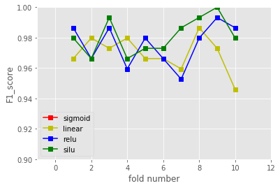

```
mean f1 of sigmoid: 0.35810810810810806
mean f1 of linear: 0.9695945945945947
mean f1 of relu: 0.9756756756756756
mean f1 of silu: 0.981081081081081
```

```python
length=range(1,K_fold+1)
plt.plot(length,score_sigmoid,'s-',color = 'r',label="sigmoid")
plt.plot(length,score_linear,'s-',color = 'y',label="linear")
plt.plot(length,score_relu,'s-',color = 'b',label="relu")
plt.plot(length,score_silu,'s-',color = 'g',label="silu")
plt.xlabel("fold number")
plt.ylabel("F1_score")
plt.legend(loc = "best")

plt.ylim(0.9, 1)
plt.xlim(-1, 12)
plt.show()
print('mean f1 of sigmoid:',mean_score_sigmoid)
print('mean f1 of linear:',mean_score_linear)
print('mean f1 of relu:',mean_score_relu)
print('mean f1 of silu:',mean_score_silu)
```

From the above figure we can see the performance of three of the four phi functions are very similar, however the performance of the sigmoid function is significantly lower than the rest, so much so that to picture it in the above figure would ruin the scale of the graph.

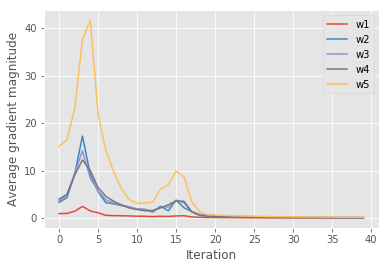

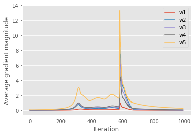

```python
relu_cross_entropy = FinalMultiLayerPerceptron(n_layers=5, n_hidden=40, epochs=50,C=0.1 ,\
                           eta=0.001,phi="relu",objective_function="cross_entropy")

relu_cross_entropy.fit( X_train, Y_train )

sigmoid_cross_entropy = FinalMultiLayerPerceptron(n_layers=5, n_hidden=40, epochs=1000,C=0.1 ,\
                           eta=0.001,phi="sigmoid",objective_function="cross_entropy")

sigmoid_cross_entropy.fit( X_train, Y_train )

draw(relu_cross_entropy)
draw(sigmoid_cross_entropy)
```

Compared to sigmoid, the gradient magnitude of Relu is much larger. That's why it converges more quickly. Relu reduces the gradient vanish problem to a certain extent, but it does not solve it.